# [Josef Urban](http://cs.ru.nl/~urban), Radboud University Nijmegen

## AI over Large Formal Knowledge Bases: The First Decade

# AI over Large Formal Knowledge Bases: The First Decade

### [Josef Urban](http://cs.ru.nl/~urban), Radboud University Nijmegen

# Talk Structure

- AI for Formal Math or Formal Math for AI?
- The semantic AI Plan: Large KBs of formal thought + evolving AI tools
- Premise selection for Mizar/MML, Isabelle/HOL, HOL/Flyspeck, etc.
- ATP guidance: E, Prover9, BliStr
- Larger AI systems: MaLARea, MaLeCoP
- Some lessons learned so far
- Some challenges

# AI for Formal Math or FM for AI?

- AI/ATP for ITP getting popular ([Sledgehammer](http://isabelle.in.tum.de/website-Isabelle2009/sledgehammer.html)), but it is only one way of looking at it
- My motivation has been (also) opposite:
- *Get to strong AI via a large repository of computer-understandable complex human thought*
- Formal math proofs/theories: good (best?) approximation? Better than scanning books?
- Gradually learn how math/science is done:
- What are the components (inductive/deductive thinking)? How to combine them together?

# The Plan

1. Make large KBs of *formal thought* (Mizar/MML, HOL/Flyspeck, Isabelle) accessible to strong AI tools: DONE (or well under way)
2. Test/Use/Evolve AI tools:
   - deductive AI: first-order/higher-order/inductive ATPs, SMTs, decision procs.
   - inductive AI: statistical learning tools (Bayesian, kernels, neural,...),
   - inductive AI: semantic learning tools (ILP - Progol, Alef, ..; latent semantics - PCA; genetic methods, ... )

# The Plan (continued)

3. Build custom/combined inductive/deductive tools/metasystems:
   - usually combining ATP/symbolic techniques with ML/statistical ideas
   - (statistically governed, "greedy", ...) indexing, subsumption, abstraction, limited inference/induction, concept/lemma creation, strategy generation, etc.
4. Continuously test performance
5. Define harder AI tasks as the performance grows (prove theorems from more basic lemmas, develop whole theories, ...)
6. GOTO 2

# The Plan (continued)

- Corollary: It happens to be useful (Mizar, Isabelle, HOL, etc)
- Large-scale benchmarks crucial for feedback/progress (this is highly experimental science!)
- Define benchmarks: whole MML, [MPTP Challenge](http://www.cs.miami.edu/~tptp/MPTPChallenge/), [CASC LTB](http://www.cs.miami.edu/~tptp/CASC/J4/Design.html#Changes), MPTP2078, [MZR@Turing](http://www.cs.miami.edu/~tptp/CASC/J6/Design.html#CompetitionDivisions)
- Otherwise many seemingly "cool" ideas that subsume each other in unexpected ways
- Implementation matters and is the proof of the pudding
- Observation: This plan seems to have taken off in the last decade
- Enter the CASC LTB 2013 competition!! (Mizar, Isabelle, HOL, 1-day pre-training)

# Corpora

- Mizar/MML: today about 50-100k formal math theorems/proofs (``Bourbaki'') written by humans (link to MML Query with the known theorems)
- An interesting AI repository, first translated for AI/ATP experiments in 2003
- Isabelle/HOL: about 20k theorems (but add AFP!), first translated for ATP experiments in ca. 2005
- Recent work to allow machine learning (2011-12: consistent naming & translation, proof export)
- HOL (Light): early translations (MESON, Metis) by Harrison and Hurd
- HOL/Flyspeck: about 20k theorems, translated for AI/ATPs recently (2012)
- More: SUMO, LogAnswer (full German Wikipedia in FOL), YAGO, ...

# AI tools: Evolving technology stack

- Try to stay on top of the stack and stimulate its progress
- ATPs: a lot of progress in handling of large KBs (parsing, indexing, heuristics)
- New/improved ATP calculi and strategies
  - instantiation-based methods (iProver, SMT)
  - (parameterized) preference of conjecture (E, leanCoP, Prover9)
  - strategy languages (E), weight/ordering specifications
  - extensive tuning for problems (Vampire, BliStr)
  - more ITP-friendly extensions (many-sorted, polymorphic)
- Great progress in statistical ML
  - Netflix Challenge (latent semantics, unsurpervised learning)
  - DARPA Challenge, Google, Yahoo, Amazon, ...
  - Bayesian inference (biochemical causal chains, ...)

# Premise Selection

- Early 2003: Can existing ATPs be used over the freshly translated Mizar library?
- About 80000 nontrivial math facts at that time.
- Is good premise selection possible at all?
- Or is it a mysterious power of mathematicians? (Penrose!)
- Today: Premise selection is not a mysterious property of mathematicians.
- Reasonably good algorithms started to appear (more below).
- Will extensive human (math) knowledge get obsolete?? (cf. Watson)

# Example: Mizar Proof Advisor (2003)

- Train premise selection on all previous Mizar/MML proofs (50k)
- Recommend relevant premises when proving new conjectures
- About 70% coverage in the first 100 recommended premises
- Chain the recommendations with strong ATPs to get full proofs
- Used today also for Isabelle/Sledgehammer and HOL/Flyspeck
- Many interesting issues: features, labels, their utility and consistency
- Still easy to improve (waiting for you!)

# Evaluation of methods on MPTP2078

ML evaluation (premise recall)

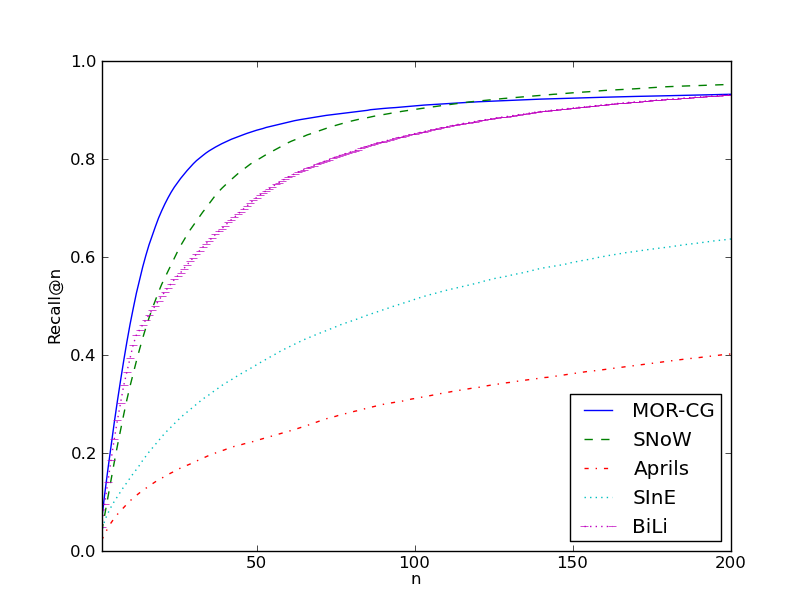

# Evaluation of methods on MPTP2078

ATP evaluation (problems solved)

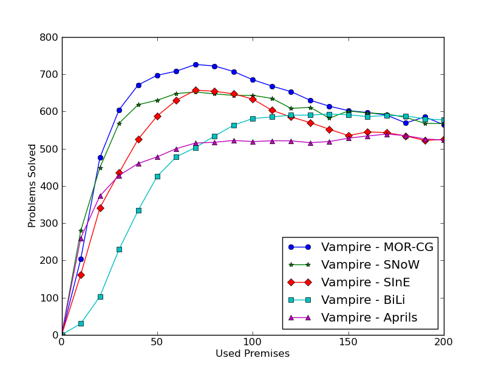

# Combined (ensemble) methods

Combining with SInE improves the best method from 726 to 797 (10%)

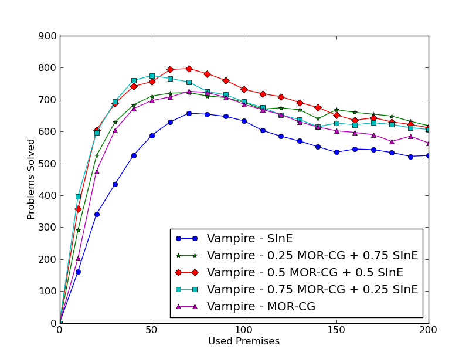

[figure not shown]

# Learning from ATP and ITP proofs

Learning from the shortest ATP proofs helps also by about 10%

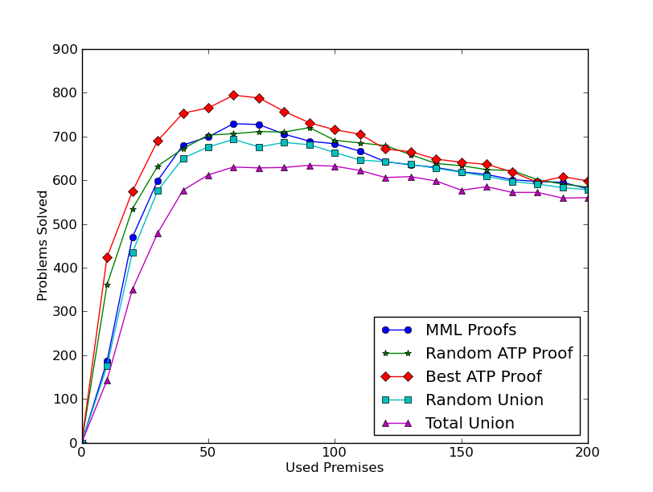

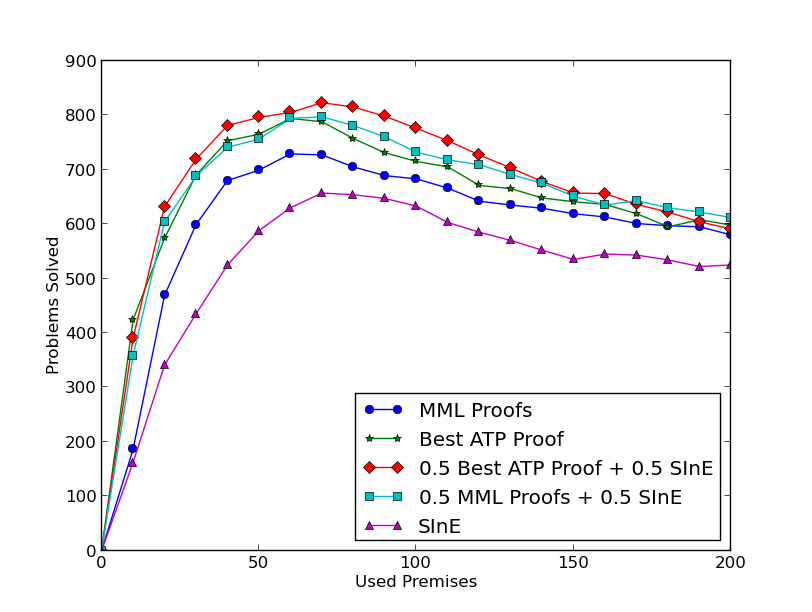

# Evaluation on Flyspeck

- 628 AI/ATP combinations evaluated so far
- they differ in the features, learning data, learning method, premise number, ATP
- [39% of top-level theorems proved by 14 AI/ATP methods - Nov 2012](http://cl-informatik.uibk.ac.at/users/cek/recheck/Table9__ho_asta.html)
- [45.5% of top-level theorems proved by recent 14 AI/ATP methods - Mar 2013](http://cl-informatik.uibk.ac.at/users/cek/recheck/Table9__ho_asta+++.html)

# Example of a simpler proof

- Mathematicians are good, but sometimes miss things
- Already in 2005: examples in Mizar where better premises found automatically
- Recent HOL Light example: FACE_OF_POLYHEDRON_POLYHEDRON
- The premise selection is good enough to rank the needed premises high
- And then the ATP is good enough to find the proof from them

# The HOL(y)Hammer AI/ATP service

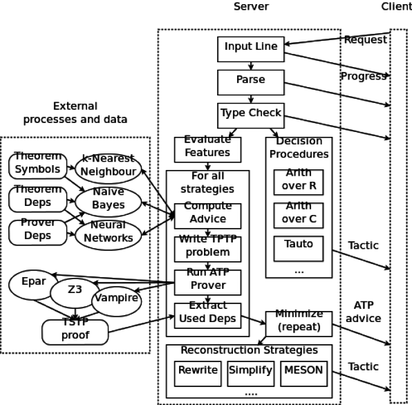

HH architecture

# Examples of AI guidance in E and Prover9

- Proof-trace guidance:
- Prover9 hints, KB of abstracted lemmas from previous proofs in E
- nearest-neighbor guidance: ConjectureRelativeSymbolWeight in E
- further symbol weighting based on axiom relevance in E
- semantic guidance: Prover9, iProver, Vampire (since 2012)

# BliStr: Blind Strategymaker, E-MaLeS

- Problem:
- Is conjecture-based guidance better than proof-trace guidance?
- In other words: how do we put all the sophisticated ATP techniques together?
- Grow a population of diverse strategies by iterative local search (and/or genetics)!
- Use clusters of similar solvable problems to train for unsolved problems
- Interleave low-time training with high-time evaluation
- Thus co-evolve the strategies and their training problems
- In the end, learn which strategy to use on which problem

# BliStr on 1000 Mizar@Turing problems

- original E coverage: 597 problems
- after 30 hours of strategy growing: 22 strategies covering 670 problems
- A selection of 14 strategies improves E auto-mode by 25% on unseen problems
- Similar results for the Flyspeck problems
- Be lazy, don't do "hard" theory-driven ATP research (a.k.a: thinking)
- In 30 hours, your ATP can self-improve by data-driven methods while you lie on a beach!

# Examples of self-evolving metasystems

- BliStr could evolve various parts of the ATP technology for long time
- Machine Learner for Automated Reasoning (MaLARea)
- Machine Learning Connection Prover (MaLeCoP)

# Machine Learner for Automated Reasoning

- MaLARea: explore & exploit, reinforcement learning, etc.
- AI feedback loop interleaving deduction with induction on a large math. theory:
- The more problems you solve (and fail to solve), the more solutions (and failures) you can learn from
- The more you can learn from, the more you solve (now also in HH)
- Systematic concept addition (models, etc.), can be dangerous
- continuous update of the learning wrt. the new concepts
- good performance on AI/ATP benchmarks ([MPTPChallenge](http://www.cs.miami.edu/~tptp/MPTPChallenge/Results/SVGResults.html), [CASC LTB 2008](http://www.cs.miami.edu/~tptp/CASC/J4/WWWFiles/LTBResultsSummary.html),[CASC Mizar 2012](http://www.cs.miami.edu/~tptp/CASC/J6/TuringWWWFiles/DivisionSummary1.html))
- The CASC performance curve flat for [quite a while](http://www.cs.miami.edu/~tptp/CASC/J6/TuringWWWFiles/ResultsPlots.html#MRTProblems)

# MaLARea Architecture

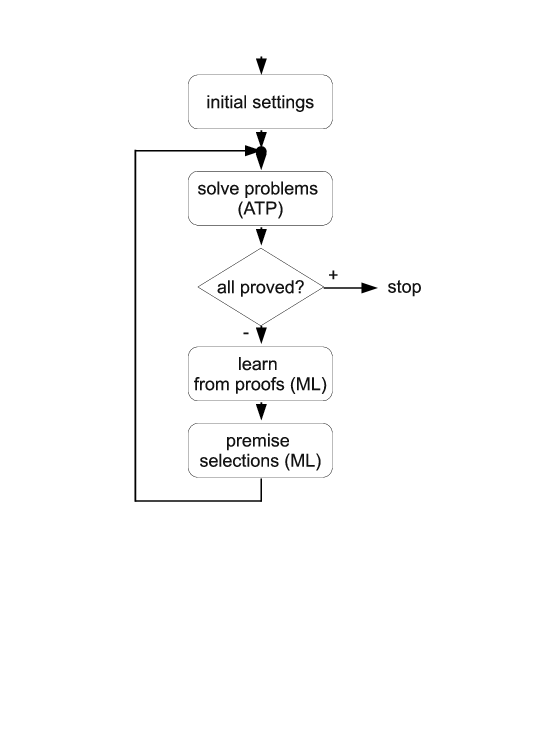

MaLARea

# Machine Learning Connection Prover

- MaLeCoP: put the AI methods inside a tableau ATP
- the learning/deduction feedback loop runs across problems and inside problems
- The more problems/branches you solve/close, the more solutions you can learn from
- The more solutions you can learn from, the more problems you solve
- Not just model avoidance, also ``dangerous pattern'' avoidance
- still quite a prototype (no CASC)
- already about 20-time proof search shortening on MPTP Challenge compared to leanCoP (see the [paper](http://dx.doi.org/10.1007/978-3-642-22119-4_21))

# MaLeCoP Architecture

[figure not shown]

MaLeCoP

# Some lessons learned

- Don't push "expensive AI" where "normal AI" is better, do the obvious first:
- statistical ML vs. symbolic (ILP, etc): needs to be carefully merged: statistical substitution/subsumption trees, ATPs testing generalizations, etc.
- high-level combination of standard ATPs and learning vs. low-level new "cool" (often non-performing) systems (lots of work on MaLeCoP to make it efficient)
- make it useful (Sledgehammer, MizAR, HOL(y)Hammer) and have rigorous benchmarks (CASC LTB, etc.)

# Some lessons learned

- one's own sense of "AI coolness" may be totally wrong on the large scale
- large-scale evaluations will show what is good and what to do next (analyze data often!)
- simple ML methods applied at the right place can be very powerful (recently e.g. BliStr)
- the formal domain is very fragile and takes a lot of work, but also very rewarding:
  - new ATP proofs cannot be trusted/learned from if the translation to ATPs is unsound (funny story with Isabelle)
  - once the translation is correct, new AI/ATP proofs really emerge

# Challenges in large formal KBs

- selection of knowledge (for ATPs and humans)
- useful translations between logics, useful ATP calculi and decision procedures
- training internal guidance of ATPs, SMTs, automation inside ITPs
- developing the corpora: lemmas, concepts, conjectures, (counter)examples

# transfer ideas from SAT to malecop and E

- Alan Frisch claims that using dynamic features the saT/unsat could be guessed with 75% success on random sat problems
- dynamic features: random hill-climbing to get as much clauses true, etc

# Challenges in large formal KBs

- refactoring of long ATP proofs for human consumption (50k-long proof by David Stanovsky & Waldmeister)
- using strong AI/ATP to help disambiguation/understanding of natural-language math
- emulating the layer on which mathematicians think (related to natural language)
- what will it take to prove Brouwer or Jordan fully automatically?

# Acknowledgments

- [Prague Automated Reasoning Group](http://arg.mff.cuni.cz/)
  - Petr Stepanek, Jiri Vyskocil, Petr Pudlak, David Stanovsky, Krystof Hoder, Jan Jakubuv, Ondrej Kuncar, Martin Suda, ...
- HOL(y)Hammer: [Cezary Kaliszyk](http://cl-informatik.uibk.ac.at/users/cek/) (Innsbruck)
- ATP and ITP people
  - Stephan Schulz, Geoff Sutcliffe, Larry Paulson, Tobias Nipkow, Jasmin Blanchette, John Harrison, Tom Hales, Andrzej Trybulec, Piotr Rudnicki, Ingo Dahn, Bill McCune, Adam Pease, Andrej Voronkov, Kostya Korovin, ...
- Learning2Reason
  - Evgeni Tsivtsivadze, Daniel Kuehlwein, Tom Heskes, Herman Geuvers ....
- ... and many more ...

# Thanks for your Attention!

- Don't forget to submit your coolest system to CASC-LTB 2013!
- Questions, Comments, ... ?